# 911 calls project

Fahad BinThabit

14/12/2020

[figure not shown]

# DATASET

## Overview

- Created by Congress in 2004 as the 911 Implementation and Coordination Office (ICO), the National 911 Program is housed within the National Highway Traffic Safety Administration at the U.S. Department of Transportation and is a joint program with the National Telecommunication and Information Administration in the Department of Commerce.
- Montgomery County, is located in the Commonwealth of Pennsylvania. As of the 2010 census, the population was 799,874 making it the third-most populous county in Pennsylvania.

For more information about dataset : https://www.kaggle.com/mchirico/montcoalert

## Variables

**lat** latitude

**lng** longitude

**desc** Description of location

**zip** zipcode

**title** type and subtype of emergency. *i.e EMS : Respiratory emergency*

**timeStamp** time of incident

**twp** district

**addr** street name and intersections

**e** dummy variable (for indexing)

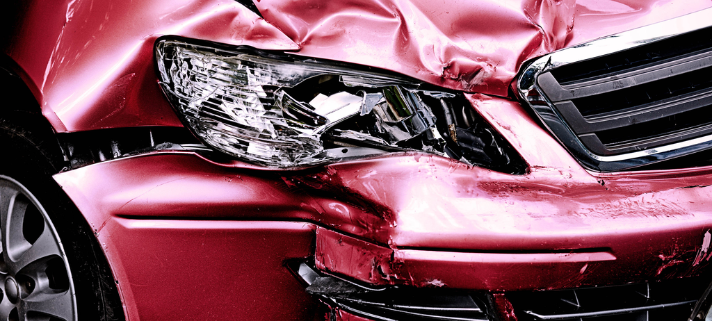

# Case study : Accidents

The data consist of 663K emergency 911 calls made in Montegomry County PA from 2015 to 2020 , these calls consist of three types “Traffic, EMS and Fire”.

*Calls are distributed into three types*

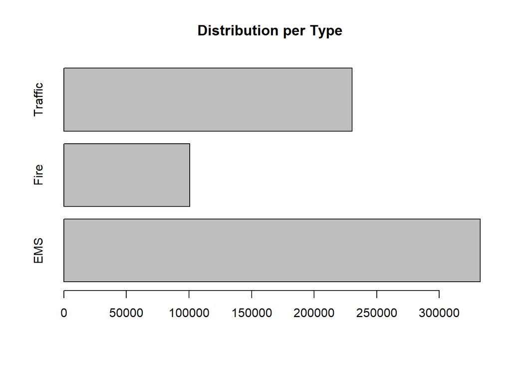

EMS(emergency medical service) 332692 Fire 100622 Traffic 230208 we have 230K traffic incident calls accident in 5 years

These traffic incidents could be a disabled vehicles or road blocks report calls , we will fetch only the vehicle accident calls

The number of calls of accidents is *129909* after fetching only accidents and removed duplicates (calls made on same accidents)

*Are there any trends during the five years ?*

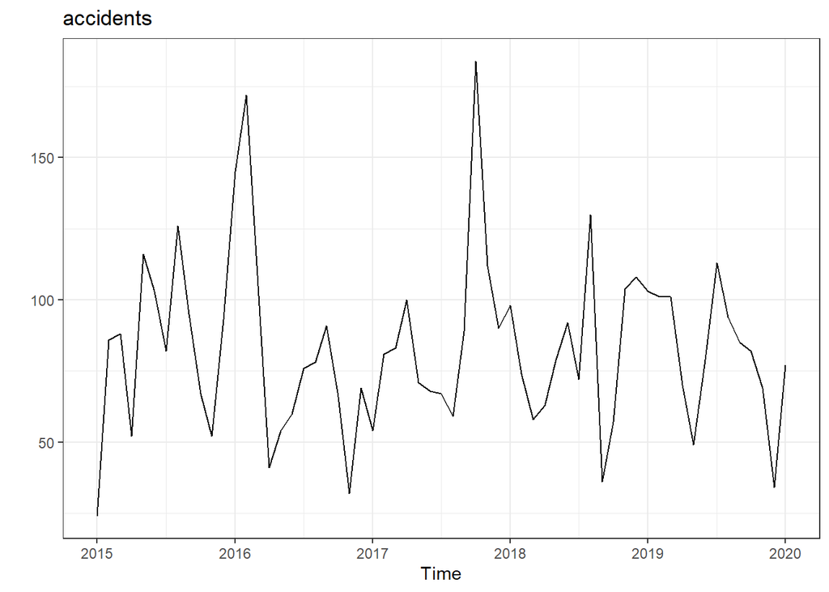

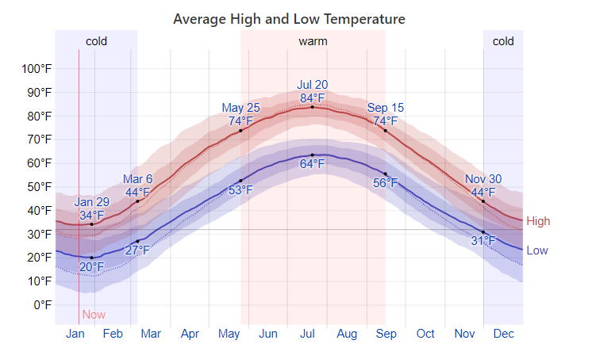

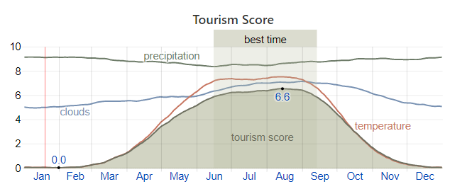

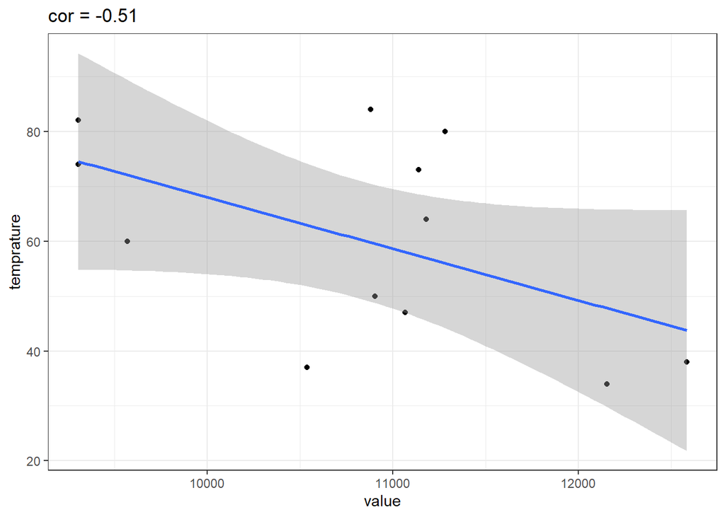

```
## [1] -0.5193862
```

let us dig deep and check the daily behavior of accidents

*what time of the day accidents are happening ?*

[interactive chart not shown]

Accidents are mainly happening during rush hour the data tells us that the daily time average of accidents are during work time

*which road has the highest frequency of accidents ?*

We picked the top 5 roads/ intersections that have the highest frequency of accidents

[interactive chart not shown]

*what about seasons or monthly avaerage for the past 5 years ?*

[interactive chart not shown]

[figure not shown]

*How about we check the correlation between the two plots*

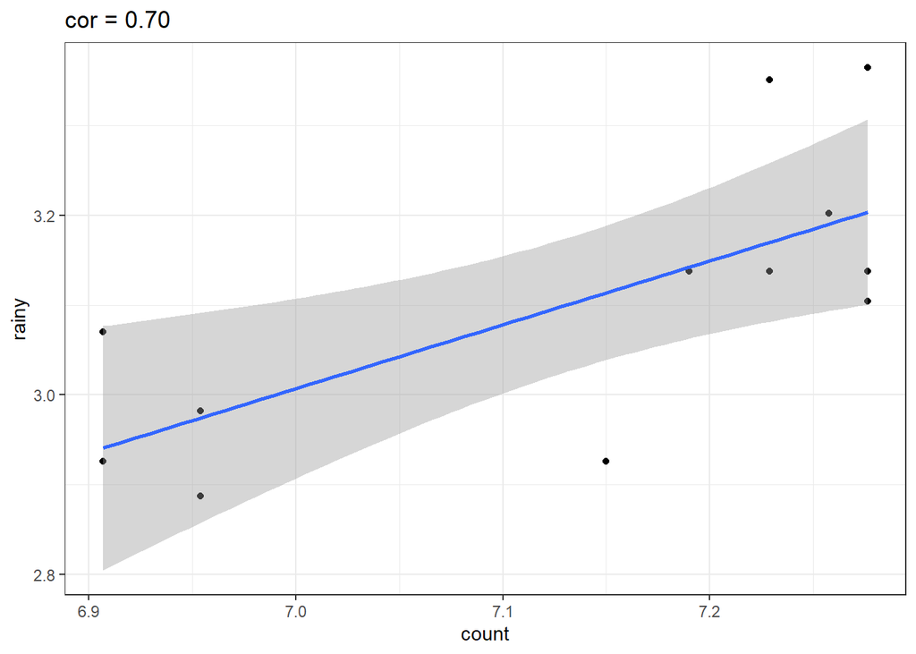

```
## [1] 0.700416
```

The coorelation is 70% which is very good

*let us do a forecast machine learning module*

we split the data set into training and testing set,

train 2015 - 2018

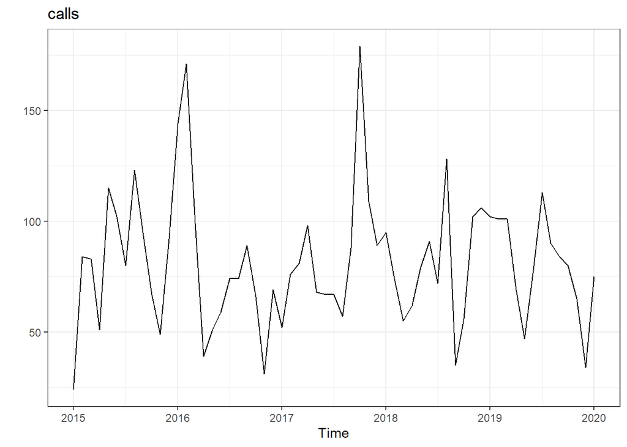

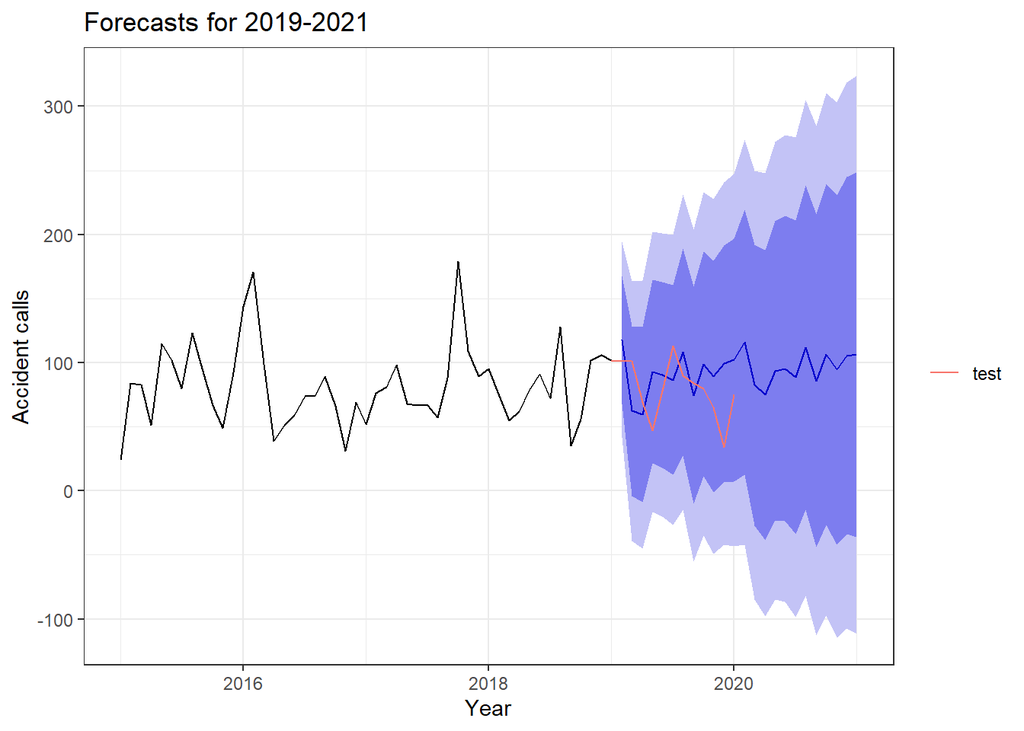

### Forecast method

we will look at the training and test comparison

```
##                     ME     RMSE      MAE       MPE     MAPE      MASE
## Training set  -4.38301 30.30163 18.97736 -13.18692 27.89801 0.5033423
## Test set     -12.15028 30.56086 26.09190 -29.51624 43.87989 0.6920431
##                    ACF1 Theil's U
## Training set -0.1103683        NA
## Test set      0.1188823  1.001355
```

let us remove the trends and smooth the plot

```
##
## Forecast method: ARIMA(4,1,0)(0,1,1)[12]
##
## Model Information:
## Series: train
## ARIMA(4,1,0)(0,1,1)[12]
##
## Coefficients:
##           ar1      ar2      ar3      ar4     sma1
##       -0.1306  -0.5475  -0.0631  -0.4685  -0.7239
## s.e.   0.1491   0.1602   0.1669   0.1672   0.5089
##
## sigma^2 estimated as 1451:  log likelihood=-183.87
## AIC=379.74   AICc=382.64   BIC=389.24
##
## Error measures:
##                    ME     RMSE      MAE       MPE     MAPE      MASE       ACF1
## Training set -4.38301 30.30163 18.97736 -13.18692 27.89801 0.5033423 -0.1103683
##
## Forecasts:
##          Point Forecast      Lo 80    Hi 80      Lo 95    Hi 95
## Feb 2019      118.01165  68.034019 167.9893   41.57746 194.4458
## Mar 2019       62.42279  -3.798357 128.6439  -38.85371 163.6993
## Apr 2019       59.70439  -8.654896 128.0637  -44.84212 164.2509
## May 2019       93.04789  21.521411 164.5744  -16.34242 202.4382
## Jun 2019       90.53096  18.184670 162.8772  -20.11314 201.1751
## Jul 2019       86.56386  12.597943 160.5298  -26.55725 199.6850
## Aug 2019      108.28794  27.720855 188.8550  -14.92878 231.5047
## Sep 2019       74.65927 -10.037082 159.3556  -54.87262 204.1912
## Oct 2019       98.86597  11.250487 186.4815  -35.13035 232.8623
## Nov 2019       89.29706  -1.300137 179.8943  -49.25940 227.8535
## Dec 2019       99.30243   6.829037 191.7758  -42.12342 240.7283
## Jan 2020      102.10916   7.102723 197.1156  -43.19065 247.4090
## Feb 2020      115.94675  12.596900 219.2966  -42.11321 274.0067
## Mar 2020       82.57276 -26.915444 192.0610  -84.87500 250.0205
## Apr 2020       74.89998 -38.176362 187.9763  -98.03536 247.8353
## May 2020       93.67576 -23.064463 210.4160  -84.86301 272.2145
## Jun 2020       95.39137 -23.773267 214.5560  -86.85521 277.6379
## Jul 2020       88.75122 -33.477149 210.9796  -98.18094 275.6834
## Aug 2020      111.74742 -14.715015 238.2098  -81.66018 305.1550
```

[output cut: 15 more lines]

```
## Nov 2019       89.29706  -1.300137 179.8943  -49.25940 227.8535
## Dec 2019       99.30243   6.829037 191.7758  -42.12342 240.7283
## Jan 2020      102.10916   7.102723 197.1156  -43.19065 247.4090
## Feb 2020      115.94675  12.596900 219.2966  -42.11321 274.0067
## Mar 2020       82.57276 -26.915444 192.0610  -84.87500 250.0205
## Apr 2020       74.89998 -38.176362 187.9763  -98.03536 247.8353
## May 2020       93.67576 -23.064463 210.4160  -84.86301 272.2145
## Jun 2020       95.39137 -23.773267 214.5560  -86.85521 277.6379
## Jul 2020       88.75122 -33.477149 210.9796  -98.18094 275.6834
## Aug 2020      111.74742 -14.715015 238.2098  -81.66018 305.1550
## Sep 2020       85.97470 -43.932289 215.8817 -112.70090 284.6503
## Oct 2020      106.64433 -26.620391 239.9090  -97.16647 310.4551
## Nov 2020       94.40843 -42.019937 230.8368 -114.24075 303.0576
## Dec 2020      105.60708 -33.708286 244.9225 -107.45739 318.6716
## Jan 2021      106.26041 -36.265852 248.7867 -111.71470 324.2355
```

We will use the best module suggested by ARIMA *ARIMA(4,1,0)(0,1,1)[12]* but it does not look for good and the confidence area is very wide so we add MA = 1 and SMA = 1 to the parameter specifications, Adding both of these terms will yield an “ARIMA(0,1,1)x(0,1,1) model,” which is probably the most commonly used ARIMA model for seasonal data

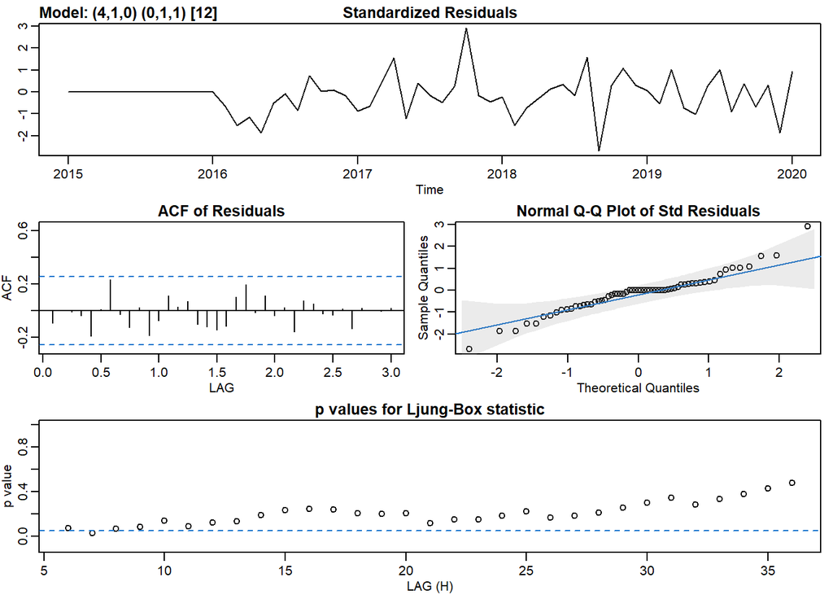

```
## $fit
##
## Call:
## stats::arima(x = xdata, order = c(p, d, q), seasonal = list(order = c(P, D,
##     Q), period = S), include.mean = !no.constant, transform.pars = trans, fixed = fixed,
##     optim.control = list(trace = trc, REPORT = 1, reltol = tol))
##
## Coefficients:
##           ar1      ar2      ar3      ar4     sma1
##       -0.2220  -0.4841  -0.1175  -0.3039  -1.0000
## s.e.   0.1402   0.1477   0.1437   0.1483   0.3798
##
## sigma^2 estimated as 973.3:  log likelihood = -243.2,  aic = 498.4
##
## $degrees_of_freedom
## [1] 43
##
## $ttable
##      Estimate     SE t.value p.value
## ar1   -0.2220 0.1402 -1.5833  0.1207
## ar2   -0.4841 0.1477 -3.2782  0.0021
## ar3   -0.1175 0.1437 -0.8182  0.4177
## ar4   -0.3039 0.1483 -2.0491  0.0466
## sma1  -1.0000 0.3798 -2.6331  0.0117
##
## $AIC
## [1] 8.447437
##
## $AICc
## [1] 8.466625
##
## $BIC
## [1] 8.637729
```

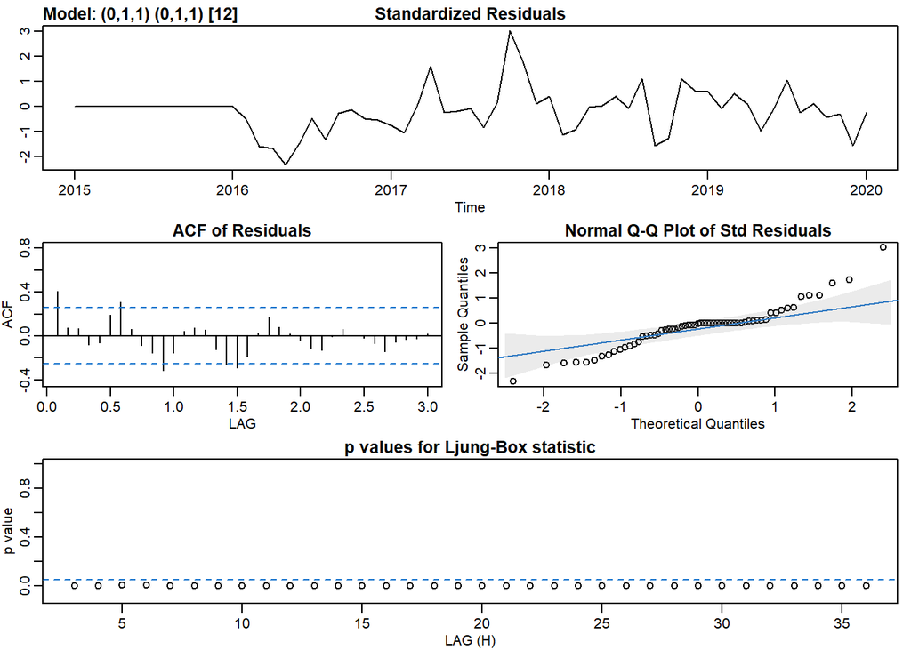

```
## $fit
##
## Call:
## stats::arima(x = xdata, order = c(p, d, q), seasonal = list(order = c(P, D,
##     Q), period = S), include.mean = !no.constant, transform.pars = trans, fixed = fixed,
##     optim.control = list(trace = trc, REPORT = 1, reltol = tol))
##
## Coefficients:
##           ma1     sma1
##       -1.0000  -0.9996
## s.e.   0.1454   0.2571
##
## sigma^2 estimated as 1006:  log likelihood = -246.19,  aic = 498.38
##
## $degrees_of_freedom
## [1] 46
##
## $ttable
##      Estimate     SE t.value p.value
## ma1   -1.0000 0.1454 -6.8797   0e+00
## sma1  -0.9996 0.2571 -3.8874   3e-04
##
## $AIC
## [1] 8.447199
##
## $AICc
## [1] 8.450831
##
## $BIC
## [1] 8.542344
```

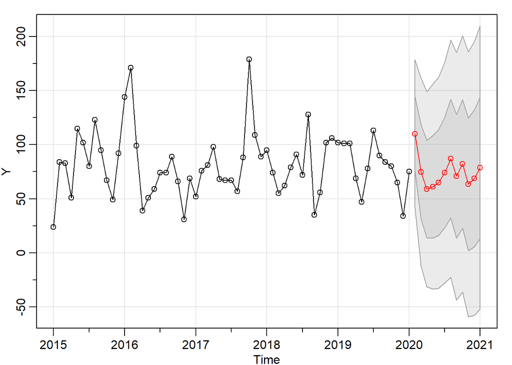

```
## $pred
##            Jan       Feb       Mar       Apr       May       Jun       Jul
## 2020           109.94127  74.73384  58.88735  61.17997  64.90190  74.11959
## 2021  78.69883
##            Aug       Sep       Oct       Nov       Dec
## 2020  87.12250  70.86260  82.16474  63.46814  68.74160
## 2021
##
## $se
##           Jan      Feb      Mar      Apr      May      Jun      Jul      Aug
## 2020          34.30887 43.50577 45.04040 47.39042 48.75348 51.03639 54.77302
## 2021 65.45077
##           Sep      Oct      Nov      Dec
## 2020 57.17765 59.24860 61.26801 63.23185
## 2021
```

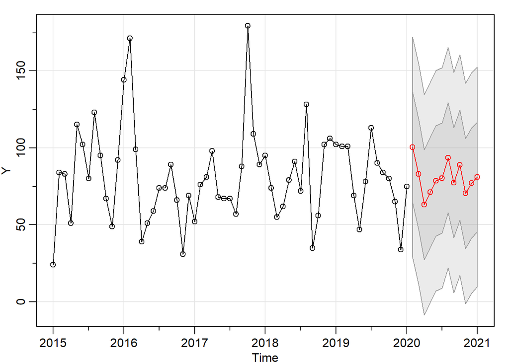

```
## $pred
##            Jan       Feb       Mar       Apr       May       Jun       Jul
## 2020           100.40005  83.00006  63.00007  71.20005  78.60006  80.40007
## 2021  81.06675
##            Aug       Sep       Oct       Nov       Dec
## 2020  93.60006  77.40006  88.80006  70.40007  77.20004
## 2021
##
## $se
##           Jan      Feb      Mar      Apr      May      Jun      Jul      Aug
## 2020          35.73853 35.73853 35.73853 35.73853 35.73853 35.73853 35.73853
## 2021 35.62805
##           Sep      Oct      Nov      Dec
## 2020 35.73853 35.73853 35.73853 35.73853
## 2021
```